# **Advanced lecture: 공학 예제 실습 Ⅰ (Kriging)**

By Mingyu Lee and Ikjin Lee

http://idol.kaist.ac.kr/

mglee91@kaist.ac.kr

https://github.com/MingyuLee91

IDOL Lab at KAIST

### **< Source papers >**

- Le Gratiet, L. (2013). Multi-fidelity Gaussian process regression for computer experiments (Doctoral dissertation, Université Paris-Diderot-Paris VII).
- **Lee, M.**, Jung, Y., Choi, J., & Lee, I. (2022). A reanalysis-based multi-fidelity (RBMF) surrogate framework for efficient structural optimization. Computers & Structures, 273, 106895.
- **Lee, M.**, Noh, Y., & Lee, I. (2024). A novel sampling method for adaptive gradient-enhanced Kriging. Computer Methods in Applied Mechanics and Engineering, 418, 116456.

Original source codes from https://github.com/SMTorg/SMT

Modified version by Mingyu Lee

### **< Contents >**

1) Optimization example

2) One-dimensional example (Kriging)

3) One-dimensional example (Co-Kriging)

**4) Engineering application (Kriging)**

5) Engineering application (Co-Kriging)

**참고:** https://seong6496.tistory.com/317

```python
from google.colab import drive
drive.mount('/content/drive')
```

```python
!pip install smt
```

```
     ━━━━━━━━━━━━━━━━━━━━━━━━━━━━━━━━━━━━━━━━ 833.7/833.7 kB 14.4 MB/s eta 0:00:00
```

## **▣ 실습: Engineering application**

### ※ **공학문제 실습**

[figure not shown]

### ※ **예제 문제**

- **실습목표:** 선택된 Output에 대한 대리모델 구성 (정확성/효율성 측면에서 비교)
- **설계변수 개수:** 5개
- **설계공간:** 1.1<x<sub>1</sub><5, 1.1<x<sub>2</sub><5, 1.1<x<sub>3</sub><5, 1.1<x<sub>4</sub><5, 1.1<x<sub>5</sub><5
- **Output:** Bending loading condition일때 solebar의 수직방향으로의 처짐량
- **계산시간:** HF model (193초), LF model (3초)

```python
from __future__ import print_function, division
import numpy as np
from scipy import linalg
from smt.utils import compute_rms_error

from smt.problems import Sphere, NdimRobotArm, Rosenbrock
from smt.sampling_methods import LHS
from smt.surrogate_models import LS, QP, KPLS, KRG, KPLSK, GEKPLS, MGP
try:
    from smt.surrogate_models import IDW, RBF, RMTC, RMTB
    compiled_available = True
except:
    compiled_available = False

try:
    import matplotlib.pyplot as plt
    plot_status = True
except:
    plot_status = False

import scipy.interpolate

from mpl_toolkits.mplot3d import Axes3D
import matplotlib.pyplot as plt
from matplotlib import cm

import pandas as pd
```

## **Steps 1-3: Training data 불러오기**

```python
# 인풋&아웃풋 데이터 불러오기
df = pd.read_csv('/content/drive/MyDrive/2024_동계산학협동강좌/Engineering_data/HF15_data.csv')
print(df) # 데이터
```

```
       X_HF1     X_HF2     X_HF3     X_HF4     X_HF5   y_max_HF
0   3.185265  2.117766  3.277744  1.332242  1.981435  18.690668
1   1.245894  4.671755  1.963425  1.970023  3.019407  16.141817
2   4.711109  4.791736  4.117166  2.271515  3.996545  10.865165
3   4.932903  3.432403  1.784466  4.277447  2.710573  14.357901
4   3.853733  1.638498  3.703125  3.774090  4.330052  13.288972
5   3.545327  2.470114  1.610188  3.465033  1.832440  18.295063
6   2.331825  2.792962  2.169856  1.648360  2.337618  18.846931
7   4.323261  4.329583  3.462545  4.133118  1.129507  12.207865
8   2.475084  1.298306  4.532992  2.478326  2.652545  16.010534
9   1.822346  1.500699  1.334335  1.568569  3.832626  25.729863
10  4.189471  2.149597  4.931913  4.992059  3.396339  10.836428
11  2.842864  3.817831  4.392807  4.546541  4.745543   9.808391
12  2.057118  4.084505  3.003271  2.789994  3.514699  12.931875
13  3.069717  3.639785  2.624496  3.315220  1.489877  14.580526
14  1.487957  3.052887  2.732481  2.944772  4.617517  14.006957
```

```python
Data = df.to_numpy()
Data
```

```
array([[ 3.18526542,  2.11776589,  3.27774438,  1.33224192,  1.98143467,
        18.69066769],
       [ 1.24589381,  4.67175462,  1.96342476,  1.97002309,  3.01940674,
        16.14181721],
       [ 4.711109  ,  4.7917362 ,  4.11716604,  2.27151478,  3.996545  ,
        10.86516546],
       [ 4.93290318,  3.43240273,  1.78446647,  4.27744655,  2.71057275,
        14.35790137],
       [ 3.85373284,  1.63849792,  3.70312468,  3.77409036,  4.33005241,
        13.28897247],
       [ 3.54532702,  2.47011398,  1.61018789,  3.46503265,  1.83244016,
        18.29506334],
       [ 2.33182495,  2.79296167,  2.16985632,  1.64836015,  2.33761768,
        18.8469311 ],
       [ 4.3232608 ,  4.32958348,  3.46254542,  4.13311761,  1.1295069 ,
        12.20786515],
       [ 2.4750839 ,  1.29830627,  4.53299219,  2.47832608,  2.65254472,
        16.01053411],
       [ 1.82234585,  1.5006993 ,  1.33433481,  1.56856945,  3.83262564,
        25.72986326],
       [ 4.18947141,  2.14959698,  4.93191349,  4.99205935,  3.39633894,
        10.83642814],
       [ 2.84286427,  3.81783051,  4.39280722,  4.54654069,  4.74554303,
         9.8083907 ],
       [ 2.05711764,  4.08450468,  3.00327073,  2.78999417,  3.51469944,
        12.93187541],
       [ 3.06971664,  3.63978546,  2.62449618,  3.31522024,  1.48987738,
        14.58052619],
       [ 1.48795685,  3.05288659,  2.73248085,  2.94477222,  4.61751702,
        14.00695652]])
```

```python
# 인풋 데이터
xt = Data[:,:5]
print(xt) # 인풋 데이터
```

```
[[3.18526542 2.11776589 3.27774438 1.33224192 1.98143467]
 [1.24589381 4.67175462 1.96342476 1.97002309 3.01940674]
 [4.711109   4.7917362  4.11716604 2.27151478 3.996545  ]
 [4.93290318 3.43240273 1.78446647 4.27744655 2.71057275]
 [3.85373284 1.63849792 3.70312468 3.77409036 4.33005241]
 [3.54532702 2.47011398 1.61018789 3.46503265 1.83244016]
 [2.33182495 2.79296167 2.16985632 1.64836015 2.33761768]
 [4.3232608  4.32958348 3.46254542 4.13311761 1.1295069 ]
 [2.4750839  1.29830627 4.53299219 2.47832608 2.65254472]
 [1.82234585 1.5006993  1.33433481 1.56856945 3.83262564]
 [4.18947141 2.14959698 4.93191349 4.99205935 3.39633894]
 [2.84286427 3.81783051 4.39280722 4.54654069 4.74554303]
 [2.05711764 4.08450468 3.00327073 2.78999417 3.51469944]
 [3.06971664 3.63978546 2.62449618 3.31522024 1.48987738]
 [1.48795685 3.05288659 2.73248085 2.94477222 4.61751702]]
```

```python
# 아웃풋 데이터
yt = Data[:,5:]
print(yt) # 아웃풋 데이터
```

```
[[18.69066769]
 [16.14181721]
 [10.86516546]
 [14.35790137]
 [13.28897247]
 [18.29506334]
 [18.8469311 ]
 [12.20786515]
 [16.01053411]
 [25.72986326]
 [10.83642814]
 [ 9.8083907 ]
 [12.93187541]
 [14.58052619]
 [14.00695652]]
```

```python
# 차원 및 초기 데이터 개수
ndoe = xt.shape[0] # 초기 데이터 개수
ndim = xt.shape[1] # 설계 변수 개수 (차원)
print("Training data 개수",ndoe)
print("설계변수 개수",ndim)
```

```
Training data 개수 15
설계변수 개수 5
```

## **Step 4: 대리 모델 구성 (Single-fidelity prediction model: Kriging)**

```python
# 대리모델링 (Main process)
initial_theta = [1e-2]*ndim # 초기 하이퍼파라미터 설정
sm = KRG(theta0 = initial_theta,print_prediction = False)
sm.set_training_values(xt,yt[:,0]) # 하이퍼파라미터 최적화
sm.train() # 하이퍼파라미터 최적화


# 하이퍼파라미터 변화
print("initial theta values",  initial_theta)
print("optimal theta values",  sm.optimal_theta)
```

```
___________________________________________________________________________

                                  Kriging
___________________________________________________________________________

 Problem size

      # training points.        : 15

___________________________________________________________________________

 Training

   Training ...
   Training - done. Time (sec):  0.2309706
initial theta values [0.01, 0.01, 0.01, 0.01, 0.01]
optimal theta values [0.00011331 0.0536155  0.02422117 0.05974524 0.00170043]
```

## **Step 5: 모델 검증**

```python
# 모델 검증용 데이터 생성
df_test = pd.read_csv('/content/drive/MyDrive/2024_동계산학협동강좌/Engineering_data/HF100_data.csv')
HF_test = df_test.to_numpy()
xtest = HF_test[:,:5]
ytest = HF_test[:,5:]

ntest = xtest.shape[0]
print(ntest)
```

```
100
```

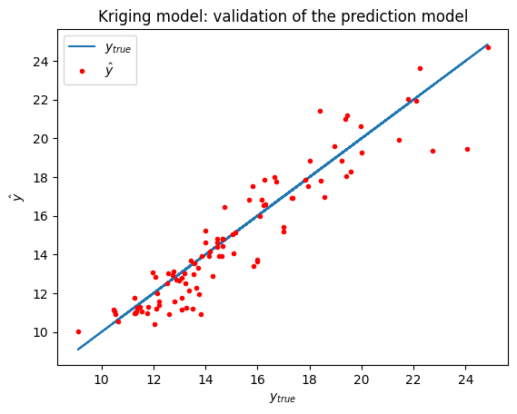

```python
# Prediction of the validation points
y_pred = sm.predict_values(xtest) # 최적화된 하이퍼파라미터가 적용된 크리깅 평균값 예측 모델

if plot_status:
    # Plot the function, the prediction and the 95% confidence interval based on
    # the MSE
    fig = plt.figure()
    plt.plot(ytest, ytest, '-', label='$y_{true}$')
    plt.plot(ytest, y_pred, 'r.', label='$\hat{y}$')

    plt.xlabel('$y_{true}$')
    plt.ylabel('$\hat{y}$')

    plt.legend(loc='upper left')
    plt.title('Kriging model: validation of the prediction model')

if plot_status:
    plt.show()
```

```python
from sklearn.metrics import mean_squared_error, r2_score

# The root mean squared error
print("Root mean squared error(RMSE): %.5f"
      % mean_squared_error(ytest, y_pred)**0.5)

# R2
print("R2: %.5f"
      % r2_score(ytest,y_pred))
```

```
Root mean squared error(RMSE): 1.21760
R2: 0.86213
```

## **최적화 수행**

### ※ **예제 문제**

```python
from scipy.optimize import minimize, differential_evolution
import numpy as np
import matplotlib.pyplot as plt
```

```python
def obj(x): # 목적함수
    x = x[np.newaxis,:]
    return 1.3*x[0,0]+1*x[0,1]+3*x[0,2]+1.1*x[0,3]+3.8*x[0,4]
```

```python
def constr(x): # 제한조건함수
    x = x[np.newaxis,:]
    return -np.squeeze(sm.predict_values(x))+20
```

```python
bnds = [(1.1,5),(1.1,5),(1.1,5),(1.1,5),(1.1,5)] # 경계값
```

```python
ineq_cons = {'type': 'ineq', 'fun': constr} # 제한조건 설정
```

```python
initial_points = np.array([3.0, 3.0, 3.0, 3.0, 3.0], dtype = 'float64') # 초기값
```

```python
print("Initial input",initial_points)
print("Initial obj",obj(initial_points))
```

```
Initial input [3. 3. 3. 3. 3.]
Initial obj 30.599999999999998
```

```python
# 최적화 수행
result = minimize(obj,initial_points,method='SLSQP',bounds=bnds,constraints=ineq_cons) # Gradient-based optimization
```

```python
result
```

```
 message: Optimization terminated successfully
 success: True
  status: 0
     fun: 13.952372398448482
       x: [ 1.100e+00  3.832e+00  1.100e+00  1.100e+00  1.100e+00]
     nit: 9
     jac: [ 1.300e+00  1.000e+00  3.000e+00  1.100e+00  3.800e+00]
    nfev: 55
    njev: 9
```

```python
x_opt = result.x
f_opt = result.fun

print("Optimal input",x_opt)
print("Minimum",f_opt)
print("Contraint_violation",constr(x_opt))
```

```
Optimal input [1.1       3.8323724 1.1       1.1       1.1      ]
Minimum 13.952372398448482
Contraint_violation -1.179238395820903e-08
```